# Análisis de texto

Guiselle Tatiana Zambrano Penagos

31/10/2020

En este caso práctico haremos una revisión general de cómo podemos analizar y procesar textos desde una perspectiva descriptiva.

El caso está estructurado así:

1. Carga y exploración de texto
2. Procesos de limpieza y transformación en texto
3. Representaciones de conteos

**Contexto:** Muchas empresas y entidades estan monitoreando constantemente los comentarios que hay en redes sociales sobre sus productos y servicios para identificar rápidamente molestias e inquietudes de sus clientes. Así poder tomar decisiones y medidas eficientemente evitando que su imagen se vea damnificada

**Pregunta de negocio:** En este caso analizaremos una muestra de tweets relacionados con el banco Davivienda. El objetivo es analizar cuáles pueden ser los temas tendencia en estos tweets y qué hallazgos se encuentran en ellos

```r
# ruta directorio
#setwd('C:/Users/Juliana/Desktop/Diplomado/D_2020/Casos/Casos/TextMining')
setwd('/root/Documentos/UN/UN_2020_2/DCD/module_4/class_6/r_project')

# cargue librerias
library(tokenizers)
library(tidyverse)
library(tm)
library(stopwords)
library(textstem)
```

```r
library(wordcloud)
library(udpipe)
library(dplyr)
```

```r
## Cargue de datos
tx <- read.csv('data/tweets.csv', header=TRUE, stringsAsFactors=FALSE, fileEncoding="latin1")
head(tx)
```

```
##                                                                                                                                                                                                                                             texto
## 1                               RT @davicorredores: Actualizamos nuestro pronóstico de inflación, ahora en @davivienda esperamos una inflación de 3.97% al finalizar 2019. Conozca más aquí #PresentaciónSemanal #Mercados #Acciones #Colcap #TES
## 2                         Explicó que en lo corrido del año los resultados del grueso de las compañías son saludables, jalonados por menores impuestos, menor apalancamiento y costo de crédito, lo cual favorece las utilidades. #ValoraAnalitik
## 3                                                                                                                       Nuevo #TipoDeCambio en Banco Davivienda (Costa Rica) S.A Compra: ¢591,00 ?? Venta: ¢605,00 ?? Diferencial: ¢14,00 $CRCUSD
## 4                                                                                                                                                                      No les pasa que se sienten como davivienda. Ya uno no puede ni pensar ????
## 5                                                   Actualizamos nuestro pronóstico de inflación, ahora en @davivienda esperamos una inflación de 3.97% al finalizar 2019. Conozca más aquí #PresentaciónSemanal #Mercados #Acciones #Colcap #TES
## 6 RT @cathurtadof: Estoy en @JardinplazaCC y los cajeros de @davivienda están en remodelación y el unico que quedaba se encuentra sin efectivo. Me siento en el lugar equivocado, en el centro comercial y sin dinero que gastar @LugarEquivocado
```

## Manejo de textos

**Tokenizar oraciones**

```r
# tokenizar oraciones
tokenize_sentences(as.character(tx[1,1]))
```

```
## [[1]]
## [1] "RT @davicorredores: Actualizamos nuestro pronóstico de inflación, ahora en @davivienda esperamos una inflación de 3.97% al finalizar 2019."
## [2] "Conozca más aquí #PresentaciónSemanal #Mercados #Acciones #Colcap #TES"
```

**Tokenizar palabras**

```r
# tokenizar palabras
tokenize_words(as.character(tx[2,1]))
```

```
## [[1]]
##  [1] "explicó"        "que"            "en"             "lo"
##  [5] "corrido"        "del"            "año"            "los"
##  [9] "resultados"     "del"            "grueso"         "de"
## [13] "las"            "compañías"      "son"            "saludables"
## [17] "jalonados"      "por"            "menores"        "impuestos"
## [21] "menor"          "apalancamiento" "y"              "costo"
## [25] "de"             "crédito"        "lo"             "cual"
## [29] "favorece"       "las"            "utilidades"     "valoraanalitik"
```

**Tamaño de tweets**

```r
# tamaño de los tweets
tx$largo = nchar(as.character(tx$texto))
mean(tx$largo)
```

```
## [1] 183.0334
```

```r
min(tx$largo)
```

```
## [1] 13
```

```r
max(tx$largo)
```

```
## [1] 578
```

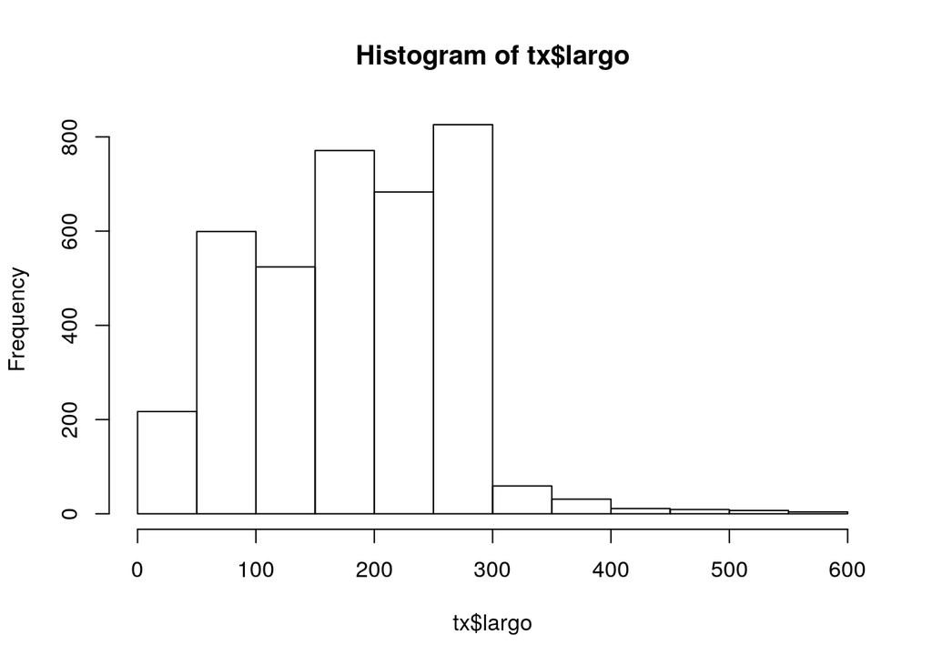

```r
hist(tx$largo)
```

## Palabras o tokens mas frecuentes

```r
## tokens mas frecuentes
palabras <- paste(tx$texto,collapse='\n')
words <- tokenize_words(palabras,lowercase = FALSE, strip_numeric = FALSE,strip_punct = FALSE)
asdf<-table(words)
tab <- tibble(word = names(asdf), count = as.numeric(asdf))
arrange(tab,desc(count))
```

```
## # A tibble: 9,431 x 2
##    word       count
##    <chr>      <dbl>
##  1 @           6148
##  2 .           5586
##  3 de          4523
##  4 ,           3826
##  5 ?           2887
##  6 :           2611
##  7 el          2593
##  8 en          2555
##  9 Davivienda  2329
## 10 #           2303
## # … with 9,421 more rows
```

```r
# to lower
as.character(tx[1,1])
```

```
## [1] "RT @davicorredores: Actualizamos nuestro pronóstico de inflación, ahora en @davivienda esperamos una inflación de 3.97% al finalizar 2019. Conozca más aquí #PresentaciónSemanal #Mercados #Acciones #Colcap #TES"
```

```r
tolower(as.character(tx[1,1]))
```

```
## [1] "rt @davicorredores: actualizamos nuestro pronóstico de inflación, ahora en @davivienda esperamos una inflación de 3.97% al finalizar 2019. conozca más aquí #presentaciónsemanal #mercados #acciones #colcap #tes"
```

**Remover @, # con expresiones regulares**

```r
# caracteres especiales
gsub('[@w+|#]','',as.character(tx[1,1]))
```

```
## [1] "RT davicorredores: Actualizamos nuestro pronóstico de inflación, ahora en davivienda esperamos una inflación de 3.97% al finalizar 2019. Conozca más aquí PresentaciónSemanal Mercados Acciones Colcap TES"
```

**Remover signos de puntuación**

```r
# puntuación
gsub('[[:punct:] ]+',' ',as.character(tx[1,1]))
```

```
## [1] "RT davicorredores Actualizamos nuestro pronóstico de inflación ahora en davivienda esperamos una inflación de 3 97 al finalizar 2019 Conozca más aquí PresentaciónSemanal Mercados Acciones Colcap TES"
```

```r
removePunctuation(as.character(tx[1,1])) # librería tm
```

```
## [1] "RT davicorredores Actualizamos nuestro pronóstico de inflación ahora en davivienda esperamos una inflación de 397 al finalizar 2019 Conozca más aquí PresentaciónSemanal Mercados Acciones Colcap TES"
```

Luego de hacer esta limpieza inicial cómo varían las palabras/tokens más frecuente

```r
# frecuencias con modificaciones
words <- tokenize_words(palabras,lowercase = TRUE, strip_numeric = FALSE,strip_punct = TRUE)
asdf<-table(words)
tab <- tibble(word = names(asdf), count = as.numeric(asdf))
arrange(tab,desc(count))
```

```
## # A tibble: 8,304 x 2
##    word       count
##    <chr>      <dbl>
##  1 de          4669
##  2 davivienda  3850
##  3 el          2977
##  4 en          2825
##  5 a           2396
##  6 la          2245
##  7 y           2108
##  8 que         2073
##  9 rt          1888
## 10 no          1422
## # … with 8,294 more rows
```

**¿Qué tipo de palabras encontramos en la lista de las más frecuentes?**

Naturalmente las palabras más comunes suelen ser “palabras vacías” que no añaden mucho significado al texto como artículos, pronombres y preposiciones. Lo más aconsejable es no considerarlas en el análisis ya que traen mucho ruido y no permiten identificar aquellas palabras que si son relevantes para el análisis

**stopwords**

```r
## stopwords
stopwords::stopwords("es")
```

```
##   [1] "de"           "la"           "que"          "el"           "en"
##   [6] "y"            "a"            "los"          "del"          "se"
##  [11] "las"          "por"          "un"           "para"         "con"
##  [16] "no"           "una"          "su"           "al"           "lo"
##  [21] "como"         "más"          "pero"         "sus"          "le"
##  [26] "ya"           "o"            "este"         "sí"           "porque"
##  [31] "esta"         "entre"        "cuando"       "muy"          "sin"
##  [36] "sobre"        "también"      "me"           "hasta"        "hay"
##  [41] "donde"        "quien"        "desde"        "todo"         "nos"
##  [46] "durante"      "todos"        "uno"          "les"          "ni"
##  [51] "contra"       "otros"        "ese"          "eso"          "ante"
##  [56] "ellos"        "e"            "esto"         "mí"           "antes"
##  [61] "algunos"      "qué"          "unos"         "yo"           "otro"
##  [66] "otras"        "otra"         "él"           "tanto"        "esa"
##  [71] "estos"        "mucho"        "quienes"      "nada"         "muchos"
```

[output cut: 47 more lines]

Removamos de nuestro texto las stopwords. Una vez hecha la limpieza ya podemos entonces verificar cuáles son las palabras más frecuentes en esta muestra de tweets

```r
# con tm
tx$texto_l <- removeWords(as.character(tx$texto),stopwords("spanish"))
palabras <- paste(tx$texto_l,collapse='\n')
words <- tokenize_words(palabras,lowercase = TRUE, strip_numeric = FALSE,strip_punct = TRUE)
asdf<-table(words)
tab <- tibble(word = names(asdf), count = as.numeric(asdf))
arrange(tab,desc(count))
```

```
## # A tibble: 8,239 x 2
##    word        count
##    <chr>       <dbl>
##  1 davivienda   3851
##  2 rt           1888
##  3 si            612
##  4 bancolombia   576
##  5 banco         522
##  6 no            510
##  7 cuenta        489
##  8 grupo         447
##  9 bancos        429
## 10 luchyb        422
## # … with 8,229 more rows
```

```r
# con la funcion tokenize_words
palabras <- paste(tx$texto,collapse='\n')
words <- tokenize_words(palabras,lowercase = TRUE, strip_numeric = FALSE,strip_punct = TRUE,stopwords = stopwords::stopwords("es"))
asdf<-table(words)
tab <- tibble(word = names(asdf), count = as.numeric(asdf))
arrange(tab,desc(count))
```

```
## # A tibble: 8,127 x 2
##    word        count
##    <chr>       <dbl>
##  1 davivienda   3850
##  2 rt           1888
##  3 si            612
##  4 bancolombia   576
##  5 banco         522
##  6 cuenta        489
##  7 grupo         447
##  8 bancos        429
##  9 luchyb        422
## 10 ud            417
## # … with 8,117 more rows
```

**n-gramas**

```r
## ngrams
# bigram
test <- tokenize_ngrams(palabras,n=2,lowercase = TRUE,stopwords = stopwords::stopwords("es"))
pre <- table(test)
tab <- tibble(ngram = names(pre), count = as.numeric(pre))
arrange(tab,desc(count))
```

```
## # A tibble: 22,092 x 2
##    ngram                  count
##    <chr>                  <dbl>
##  1 rt luchyb                402
##  2 bancolombia davivienda   268
##  3 grupo aval               246
##  4 sistema financiero       243
##  5 davivienda rt            220
##  6 banco davivienda         207
##  7 lugar equivocado         168
##  8 cuenta davivienda        160
##  9 grupo bolivar            139
## 10 davivienda ahorros       135
## # … with 22,082 more rows
```

```r
# trigram
test <- tokenize_ngrams(palabras,n=3,lowercase = TRUE,stopwords = stopwords::stopwords("es"))
pre <- table(test)
tab <- tibble(ngram = names(pre), count = as.numeric(pre))
arrange(tab,desc(count))
```

```
## # A tibble: 26,726 x 2
##    ngram                           count
##    <chr>                           <dbl>
##  1 davivienda ahorros 506100124201   134
##  2 casi quiebran davivienda          132
##  3 4 x 1000                          131
##  4 davivienda año 99                 131
##  5 x 1000 si                         131
##  6 1000 si trabajaba                 130
##  7 99 cuantos bancos                 130
##  8 año 99 cuantos                    130
##  9 bancos quebraron terminamos       130
## 10 bolivar ud irresponsable          130
## # … with 26,716 more rows
```

## Llevar texto a vectores

```r
#  matriz tdm
corp <- Corpus(VectorSource(as.character(tx$texto)))
tdm <- as.matrix(DocumentTermMatrix(corp,control = list(removePunctuation = TRUE,stopwords = TRUE)))
tdm[1:10,1:15]
```

```
##     Terms
## Docs 2019 397 acciones actualizamos ahora aquí colcap conozca davicorredores
##   1     1   1        1            1     1    1      1       1              1
##   2     0   0        0            0     0    0      0       0              0
##   3     0   0        0            0     0    0      0       0              0
##   4     0   0        0            0     0    0      0       0              0
##   5     1   1        1            1     1    1      1       1              0
##   6     0   0        0            0     0    0      0       0              0
##   7     0   0        0            0     0    0      0       0              0
##   8     0   0        0            0     0    0      0       0              0
##   9     0   0        0            0     0    0      0       0              0
##   10    0   0        0            0     0    0      0       0              0
##     Terms
## Docs davivienda esperamos finalizar inflación mercados más
##   1           1         1         1         2        1   1
##   2           0         0         0         0        0   0
##   3           1         0         0         0        0   0
##   4           1         0         0         0        0   0
##   5           1         1         1         2        1   1
##   6           1         0         0         0        0   0
##   7           1         0         0         0        0   0
##   8           1         0         0         0        0   0
##   9           1         0         0         0        0   0
##   10          1         0         0         0        0   0
```

**Wordcloud**

[figure not shown]

```r
# wordcloud
corp <- corp %>%
  tm_map(removeNumbers) %>%
  tm_map(removePunctuation) %>%
  tm_map(stripWhitespace)
corp <- tm_map(corp, content_transformer(tolower))
corp <- tm_map(corp, removeWords, stopwords("spanish"))
dtm <- TermDocumentMatrix(corp)
matrix <- as.matrix(dtm)
words <- sort(rowSums(matrix),decreasing=TRUE)
df <- data.frame(word = names(words),freq=words)

set.seed(1234) # for reproducibility
wordcloud(words = df$word, freq = df$freq, min.freq = 5,
          max.words=200, random.order=FALSE, rot.per=0.35,
          colors=brewer.pal(8, "Dark2"))
```

## Otras transformaciones de texto

**Lemmatización**

```r
vector <- c("trouble", "troubling", "troubled")
lemmatize_words(vector)
```

```
## [1] "trouble" "trouble" "trouble"
```

```r
vector <- c("corria", "corre", "corren")
lemmatize_words(vector)
```

```
## [1] "corria" "corre"  "corren"
```

**POS**

```r
## english
sent <- c("Juliana is having a good day")
df <- data.frame(sent, stringAsFactors = FALSE)
udmodel <- udpipe_download_model(language = "english")
```

```
##  - This model has been trained on version 2.5 of data from https://universaldependencies.org
```

```
##  - The model is distributed under the CC-BY-SA-NC license: https://creativecommons.org/licenses/by-nc-sa/4.0
```

```
##  - Visit https://github.com/jwijffels/udpipe.models.ud.2.5 for model license details.
```

[output not shown]

```r
udmodel <- udpipe_load_model(file = udmodel$file_model)

x <- udpipe_annotate(udmodel,df$sent)
x <- as.data.frame(x)
x %>% select(token, upos)
```

```
##     token  upos
## 1 Juliana PROPN
## 2      is   AUX
## 3  having  VERB
## 4       a   DET
## 5    good   ADJ
## 6     day  NOUN
```

```r
# spanish
sent <- c("Juliana tiene un buen día")
df <- data.frame(sent, stringAsFactors = FALSE)


udmodel <- udpipe_download_model(language = "spanish")
```

```
##  - This model has been trained on version 2.5 of data from https://universaldependencies.org
```

```
##  - The model is distributed under the CC-BY-SA-NC license: https://creativecommons.org/licenses/by-nc-sa/4.0
```

```
##  - Visit https://github.com/jwijffels/udpipe.models.ud.2.5 for model license details.
```

[output not shown]

```r
udmodel <- udpipe_load_model(file = udmodel$file_model)


x <- udpipe_annotate(udmodel,df$sent)
x <- as.data.frame(x)
x %>% select(token, upos)
```

```
##     token  upos
## 1 Juliana PROPN
## 2   tiene  VERB
## 3      un   DET
## 4    buen   ADJ
## 5     día  NOUN
```